# R Notebook

```r
#Install phyloseq
if (!requireNamespace("BiocManager", quietly = TRUE))
install.packages("BiocManager")
if (!requireNamespace("phyloseq", quietly = TRUE))
BiocManager::install("phyloseq")
packageVersion("phyloseq")
```

```
[1] ‘1.46.0’
```

```r
library("phyloseq")
library("ggplot2")      # graphics
library("readxl")       # necessary to import the data from Excel file
library("dplyr")        # filter and reformat data frames
library("tibble")       # Needed for converting column to row names
library("ape")
```

```bash
ls
```

```
HITChip.csv
Metadata.csv
Phyloseq_tutorial_presentation.pptx
Phyloseq_tutorial.Rmd
user_cases
```

#import data

```r
  otu_mat<- read_excel("../data/CARBOM data.xlsx", sheet = "OTU matrix")
  tax_mat<- read_excel("../data/CARBOM data.xlsx", sheet = "Taxonomy table")
  samples_df <- read_excel("../data/CARBOM data.xlsx", sheet = "Samples")
```

```r
head(otu_mat)
```

| otu | X10n | X10p | X11n | X11p | X120n | X120p | X121n | X121p | X122n | X122p | X125n | X125p | X126n | X126p | X127n | X13n | X13p | X140n | X140p | X141n | X141p | X142n | X142p | X155n | X155p | X156n | X156p | X157n | X157p | … |
| --- | --- | --- | --- | --- | --- | --- | --- | --- | --- | --- | --- | --- | --- | --- | --- | --- | --- | --- | --- | --- | --- | --- | --- | --- | --- | --- | --- | --- | --- | --- |
| Otu001 | 13679 | 6292 | 42 | 2500 | 18850 | 5 | 43 | 7138 | 9432 | 10541 | 9 | 9772 | 1388 | 7 | 31538 | 38 | 2338 | 23 | 9 | 1358 | 36 | 42 | 0 | 43 | 8 | 25 | 4 | 0 | 7110 | … |
| Otu002 | 18 | 7134 | 38 | 9830 | 45 | 61420 | 182 | 23751 | 36 | 11 | 4535 | 3502 | 11018 | 5473 | 26 | 14411 | 38 | 19018 | 12 | 3080 | 20 | 37 | 6855 | 56 | 29899 | 5387 | 13459 | 12 | 3900 | … |
| Otu003 | 9939 | 8983 | 31 | 13 | 24620 | 19 | 19 | 16 | 12502 | 3831 | 4621 | 2240 | 9924 | 4052 | 9292 | 18 | 0 | 37 | 7 | 3680 | 14740 | 57440 | 5712 | 47 | 25 | 18206 | 2287 | 11 | 25535 | … |
| Otu004 | 3675 | 4234 | 24 | 22 | 11 | 16 | 32967 | 35 | 6 | 18 | 6908 | 5 | 16 | 8702 | 24 | 11 | 37717 | 0 | 25 | 4196 | 4 | 9 | 5 | 31 | 21 | 2 | 14 | 9 | 4 | … |
| Otu005 | 0 | 5 | 0 | 7 | 0 | 8 | 0 | 16 | 20166 | 0 | 0 | 2 | 5 | 8 | 2 | 16 | 0 | 13 | 0 | 0 | 0 | 0 | 5 | 0 | 0 | 14 | 0 | 0 | 0 | … |
| Otu006 | 0 | 8 | 0 | 0 | 0 | 8 | 0 | 0 | 5 | 3 | 3 | 0 | 0 | 9 | 0 | 5 | 4 | 0 | 0 | 3 | 0 | 0 | 10 | 0 | 0 | 1 | 0 | 6 | 0 | … |

```r
head(tax_mat)
```

| otu | Domain | Supergroup | Division | Class | Order | Family | Genus |
| --- | --- | --- | --- | --- | --- | --- | --- |
| Otu001 | Eukaryota | Archaeplastida | Chlorophyta | Mamiellophyceae | Mamiellales | Bathycoccaceae | Ostreococcus |
| Otu002 | Eukaryota | Hacrobia | Haptophyta | Prymnesiophyceae | Prymnesiophyceae_X | Braarudosphaeraceae | UCYN_A1_host |
| Otu003 | Eukaryota | Archaeplastida | Chlorophyta | Mamiellophyceae | Mamiellales | Bathycoccaceae | Bathycoccus |
| Otu004 | Eukaryota | Alveolata | Dinophyta | Dinophyceae | Dinophyceae_X | Dinophyceae_X | Prorocentrum |
| Otu005 | Eukaryota | Stramenopiles | Ochrophyta | Bacillariophyta | Mediophyceae | Mediophyceae_X | Thalassiosira |
| Otu006 | Eukaryota | Stramenopiles | Ochrophyta | Bacillariophyta | Bacillariophyceae | Bacillariophyceae_X | Pseudo_nitzschia |

```r
head(samples_df)
```

| sample | fraction | Select_18S_nifH | total_18S | total_16S | total_nifH | sample_number | transect | station | depth | latitude | longitude | picoeuks | nanoeuks | bottom_depth | level | transect_distance | date | time | phosphates | silicates | ammonia | nitrates | nitrites | temperature | fluorescence | salinity | sample_label |
| --- | --- | --- | --- | --- | --- | --- | --- | --- | --- | --- | --- | --- | --- | --- | --- | --- | --- | --- | --- | --- | --- | --- | --- | --- | --- | --- | --- |
| X10n | Nano | Yes | 53230 | 8772 | 36 | 10 | 1 | 81 | 140 | -27.42 | -44.72 | 3278 | 1232 | 2632 | Deep | 420 | 41591 | 4.1666666666666664E-2 | 0.2 | 1.64 | 0 | 0.26 | 7.0000000000000007E-2 | 17.3 | 553.79999999999995 | 35.9 | TR1_St81_140m_10n |
| X10p | Pico | Yes | 47390 | 4448 | 6241 | 10 | 1 | 81 | 140 | -27.42 | -44.72 | 3278 | 1232 | 2632 | Deep | 420 | 41591 | 4.1666666666666664E-2 | 0.2 | 1.64 | 0 | 0.26 | 7.0000000000000007E-2 | 17.3 | 553.79999999999995 | 35.9 | TR1_St81_140m_10p |
| X11n | Nano | No | 24007 | 6193 | 3772 | 11 | 1 | 85 | 110 | -26.80 | -45.30 | 16312 | 1615 | 2100 | Deep | 330 | 41591 | 0.5625 | 0.28999999999999998 | 1.58 | 0 | 0.22 | 0.05 | 21.3 | 397.5 | 36.5 | TR1_St85_110m_11n |
| X11p | Pico | Yes | 31899 | 14 | 10201 | 11 | 1 | 85 | 110 | -26.80 | -45.30 | 16312 | 1615 | 2100 | Deep | 330 | 41591 | 0.5625 | 0.28999999999999998 | 1.58 | 0 | 0.22 | 0.05 | 21.3 | 397.5 | 36.5 | TR1_St85_110m_11p |
| X120n | Nano | Yes | 70455 | 5292 | 93 | 120 | 2 | 96 | 5 | -27.39 | -47.82 | 1150 | 75 | 111 | Surf | 86 | 41596 | 0.99305555555555547 | 0.43 | 4 | 0 | 0.19 | 0.14000000000000001 | 23.1 | 149.30000000000001 | 33.5 | TR2_St96_5m_120n |
| X120p | Pico | Yes | 76182 | 53272 | 23147 | 120 | 2 | 96 | 5 | -27.39 | -47.82 | 1150 | 75 | 111 | Surf | 86 | 41596 | 0.99305555555555547 | 0.43 | 4 | 0 | 0.19 | 0.14000000000000001 | 23.1 | 149.30000000000001 | 33.5 | TR2_St96_5m_120p |

Phyloseq objects need to have row.names

# define the row names from the otu column

```r
  otu_mat <- otu_mat %>%
    tibble::column_to_rownames("otu")
head(otu_mat)
```

|  | X10n | X10p | X11n | X11p | X120n | X120p | X121n | X121p | X122n | X122p | X125n | X125p | X126n | X126p | X127n | X13n | X13p | X140n | X140p | X141n | X141p | X142n | X142p | X155n | X155p | X156n | X156p | X157n | X157p | … |
| --- | --- | --- | --- | --- | --- | --- | --- | --- | --- | --- | --- | --- | --- | --- | --- | --- | --- | --- | --- | --- | --- | --- | --- | --- | --- | --- | --- | --- | --- | --- |
| Otu001 | 13679 | 6292 | 42 | 2500 | 18850 | 5 | 43 | 7138 | 9432 | 10541 | 9 | 9772 | 1388 | 7 | 31538 | 38 | 2338 | 23 | 9 | 1358 | 36 | 42 | 0 | 43 | 8 | 25 | 4 | 0 | 7110 | … |
| Otu002 | 18 | 7134 | 38 | 9830 | 45 | 61420 | 182 | 23751 | 36 | 11 | 4535 | 3502 | 11018 | 5473 | 26 | 14411 | 38 | 19018 | 12 | 3080 | 20 | 37 | 6855 | 56 | 29899 | 5387 | 13459 | 12 | 3900 | … |
| Otu003 | 9939 | 8983 | 31 | 13 | 24620 | 19 | 19 | 16 | 12502 | 3831 | 4621 | 2240 | 9924 | 4052 | 9292 | 18 | 0 | 37 | 7 | 3680 | 14740 | 57440 | 5712 | 47 | 25 | 18206 | 2287 | 11 | 25535 | … |
| Otu004 | 3675 | 4234 | 24 | 22 | 11 | 16 | 32967 | 35 | 6 | 18 | 6908 | 5 | 16 | 8702 | 24 | 11 | 37717 | 0 | 25 | 4196 | 4 | 9 | 5 | 31 | 21 | 2 | 14 | 9 | 4 | … |
| Otu005 | 0 | 5 | 0 | 7 | 0 | 8 | 0 | 16 | 20166 | 0 | 0 | 2 | 5 | 8 | 2 | 16 | 0 | 13 | 0 | 0 | 0 | 0 | 5 | 0 | 0 | 14 | 0 | 0 | 0 | … |
| Otu006 | 0 | 8 | 0 | 0 | 0 | 8 | 0 | 0 | 5 | 3 | 3 | 0 | 0 | 9 | 0 | 5 | 4 | 0 | 0 | 3 | 0 | 0 | 10 | 0 | 0 | 1 | 0 | 6 | 0 | … |

```r
NA
```

```r
  tax_mat <- tax_mat %>%
    tibble::column_to_rownames("otu")

  samples_df <- samples_df %>%
    tibble::column_to_rownames("sample")
head(tax_mat)
```

|  | Domain | Supergroup | Division | Class | Order | Family | Genus |
| --- | --- | --- | --- | --- | --- | --- | --- |
| Otu001 | Eukaryota | Archaeplastida | Chlorophyta | Mamiellophyceae | Mamiellales | Bathycoccaceae | Ostreococcus |
| Otu002 | Eukaryota | Hacrobia | Haptophyta | Prymnesiophyceae | Prymnesiophyceae_X | Braarudosphaeraceae | UCYN_A1_host |
| Otu003 | Eukaryota | Archaeplastida | Chlorophyta | Mamiellophyceae | Mamiellales | Bathycoccaceae | Bathycoccus |
| Otu004 | Eukaryota | Alveolata | Dinophyta | Dinophyceae | Dinophyceae_X | Dinophyceae_X | Prorocentrum |
| Otu005 | Eukaryota | Stramenopiles | Ochrophyta | Bacillariophyta | Mediophyceae | Mediophyceae_X | Thalassiosira |
| Otu006 | Eukaryota | Stramenopiles | Ochrophyta | Bacillariophyta | Bacillariophyceae | Bacillariophyceae_X | Pseudo_nitzschia |

```r
head(samples_df)
```

|  | fraction | Select_18S_nifH | total_18S | total_16S | total_nifH | sample_number | transect | station | depth | latitude | longitude | picoeuks | nanoeuks | bottom_depth | level | transect_distance | date | time | phosphates | silicates | ammonia | nitrates | nitrites | temperature | fluorescence | salinity | sample_label |
| --- | --- | --- | --- | --- | --- | --- | --- | --- | --- | --- | --- | --- | --- | --- | --- | --- | --- | --- | --- | --- | --- | --- | --- | --- | --- | --- | --- |
| X10n | Nano | Yes | 53230 | 8772 | 36 | 10 | 1 | 81 | 140 | -27.42 | -44.72 | 3278 | 1232 | 2632 | Deep | 420 | 41591 | 4.1666666666666664E-2 | 0.2 | 1.64 | 0 | 0.26 | 7.0000000000000007E-2 | 17.3 | 553.79999999999995 | 35.9 | TR1_St81_140m_10n |
| X10p | Pico | Yes | 47390 | 4448 | 6241 | 10 | 1 | 81 | 140 | -27.42 | -44.72 | 3278 | 1232 | 2632 | Deep | 420 | 41591 | 4.1666666666666664E-2 | 0.2 | 1.64 | 0 | 0.26 | 7.0000000000000007E-2 | 17.3 | 553.79999999999995 | 35.9 | TR1_St81_140m_10p |
| X11n | Nano | No | 24007 | 6193 | 3772 | 11 | 1 | 85 | 110 | -26.80 | -45.30 | 16312 | 1615 | 2100 | Deep | 330 | 41591 | 0.5625 | 0.28999999999999998 | 1.58 | 0 | 0.22 | 0.05 | 21.3 | 397.5 | 36.5 | TR1_St85_110m_11n |
| X11p | Pico | Yes | 31899 | 14 | 10201 | 11 | 1 | 85 | 110 | -26.80 | -45.30 | 16312 | 1615 | 2100 | Deep | 330 | 41591 | 0.5625 | 0.28999999999999998 | 1.58 | 0 | 0.22 | 0.05 | 21.3 | 397.5 | 36.5 | TR1_St85_110m_11p |
| X120n | Nano | Yes | 70455 | 5292 | 93 | 120 | 2 | 96 | 5 | -27.39 | -47.82 | 1150 | 75 | 111 | Surf | 86 | 41596 | 0.99305555555555547 | 0.43 | 4 | 0 | 0.19 | 0.14000000000000001 | 23.1 | 149.30000000000001 | 33.5 | TR2_St96_5m_120n |
| X120p | Pico | Yes | 76182 | 53272 | 23147 | 120 | 2 | 96 | 5 | -27.39 | -47.82 | 1150 | 75 | 111 | Surf | 86 | 41596 | 0.99305555555555547 | 0.43 | 4 | 0 | 0.19 | 0.14000000000000001 | 23.1 | 149.30000000000001 | 33.5 | TR2_St96_5m_120p |

```r
NA
```

#Transform into matrixes otu and tax tables (sample table can be left as data frame)

```r
  otu_mat <- as.matrix(otu_mat)
  tax_mat <- as.matrix(tax_mat)
```

#Phyloseq object

```r
  OTU = otu_table(otu_mat, taxa_are_rows = TRUE)
  TAX = tax_table(tax_mat)
  samples = sample_data(samples_df)

  carbom <- phyloseq(OTU, TAX, samples)
  carbom
```

```
phyloseq-class experiment-level object
otu_table()   OTU Table:         [ 287 taxa and 55 samples ]
sample_data() Sample Data:       [ 55 samples by 27 sample variables ]
tax_table()   Taxonomy Table:    [ 287 taxa by 7 taxonomic ranks ]
```

#Check against

```r
sample_names(samples)
```

```
 [1] "X10n"   "X10p"   "X11n"   "X11p"   "X120n"  "X120p"  "X121n"  "X121p"  "X122n"  "X122p"
[11] "X125n"  "X125p"  "X126n"  "X126p"  "X127n"  "X13n"   "X13p"   "X140n"  "X140p"  "X141n"
[21] "X141p"  "X142n"  "X142p"  "X155n"  "X155p"  "X156n"  "X156p"  "X157n"  "X157p"  "X15n"
[31] "X15p"   "X165n"  "X165p"  "X166n"  "X166p"  "X167n"  "X167p"  "X1n"    "X1p"    "X2n"
[41] "X2p"    "X3n"    "X3p"    "X5n"    "X5p"    "X7n"    "X7p"    "X9n"    "X9p"    "tri01n"
[51] "tri01p" "tri02n" "tri02p" "tri03n" "tri03p"
```

```r
sample_names(OTU)
```

```
 [1] "X10n"   "X10p"   "X11n"   "X11p"   "X120n"  "X120p"  "X121n"  "X121p"  "X122n"  "X122p"
[11] "X125n"  "X125p"  "X126n"  "X126p"  "X127n"  "X13n"   "X13p"   "X140n"  "X140p"  "X141n"
[21] "X141p"  "X142n"  "X142p"  "X155n"  "X155p"  "X156n"  "X156p"  "X157n"  "X157p"  "X15n"
[31] "X15p"   "X165n"  "X165p"  "X166n"  "X166p"  "X167n"  "X167p"  "X1n"    "X1p"    "X2n"
[41] "X2p"    "X3n"    "X3p"    "X5n"    "X5p"    "X7n"    "X7p"    "X9n"    "X9p"    "tri01n"
[51] "tri01p" "tri02n" "tri02p" "tri03n" "tri03p"
```

#visualize data

```r
  sample_names(carbom)
```

```
 [1] "X10n"   "X10p"   "X11n"   "X11p"   "X120n"  "X120p"  "X121n"  "X121p"  "X122n"  "X122p"
[11] "X125n"  "X125p"  "X126n"  "X126p"  "X127n"  "X13n"   "X13p"   "X140n"  "X140p"  "X141n"
[21] "X141p"  "X142n"  "X142p"  "X155n"  "X155p"  "X156n"  "X156p"  "X157n"  "X157p"  "X15n"
[31] "X15p"   "X165n"  "X165p"  "X166n"  "X166p"  "X167n"  "X167p"  "X1n"    "X1p"    "X2n"
[41] "X2p"    "X3n"    "X3p"    "X5n"    "X5p"    "X7n"    "X7p"    "X9n"    "X9p"    "tri01n"
[51] "tri01p" "tri02n" "tri02p" "tri03n" "tri03p"
```

```r
  rank_names(carbom)
```

```
[1] "Domain"     "Supergroup" "Division"   "Class"      "Order"      "Family"     "Genus"
```

```r
  taxa_names(carbom)
```

```
  [1] "Otu001" "Otu002" "Otu003" "Otu004" "Otu005" "Otu006" "Otu007" "Otu008" "Otu009" "Otu010"
 [11] "Otu011" "Otu012" "Otu013" "Otu014" "Otu015" "Otu016" "Otu017" "Otu018" "Otu019" "Otu020"
 [21] "Otu021" "Otu022" "Otu023" "Otu024" "Otu025" "Otu026" "Otu027" "Otu028" "Otu029" "Otu030"
 [31] "Otu031" "Otu032" "Otu033" "Otu034" "Otu035" "Otu036" "Otu037" "Otu038" "Otu039" "Otu040"
 [41] "Otu041" "Otu042" "Otu043" "Otu044" "Otu045" "Otu046" "Otu047" "Otu048" "Otu049" "Otu050"
 [51] "Otu051" "Otu052" "Otu053" "Otu054" "Otu055" "Otu056" "Otu057" "Otu058" "Otu059" "Otu060"
 [61] "Otu061" "Otu062" "Otu063" "Otu064" "Otu065" "Otu066" "Otu067" "Otu068" "Otu069" "Otu070"
 [71] "Otu071" "Otu072" "Otu073" "Otu074" "Otu075" "Otu076" "Otu077" "Otu078" "Otu079" "Otu080"
 [81] "Otu081" "Otu082" "Otu083" "Otu084" "Otu085" "Otu086" "Otu087" "Otu088" "Otu089" "Otu090"
 [91] "Otu091" "Otu092" "Otu093" "Otu094" "Otu095" "Otu096" "Otu097" "Otu098" "Otu099" "Otu100"
[101] "Otu101" "Otu102" "Otu103" "Otu104" "Otu105" "Otu106" "Otu107" "Otu108" "Otu109" "Otu110"
[111] "Otu111" "Otu112" "Otu113" "Otu114" "Otu115" "Otu116" "Otu117" "Otu118" "Otu119" "Otu120"
[121] "Otu121" "Otu122" "Otu123" "Otu124" "Otu125" "Otu126" "Otu127" "Otu128" "Otu129" "Otu130"
[131] "Otu131" "Otu132" "Otu133" "Otu134" "Otu135" "Otu136" "Otu137" "Otu138" "Otu139" "Otu140"
[141] "Otu141" "Otu142" "Otu143" "Otu144" "Otu145" "Otu146" "Otu147" "Otu148" "Otu149" "Otu150"
[151] "Otu151" "Otu152" "Otu153" "Otu154" "Otu155" "Otu156" "Otu157" "Otu158" "Otu159" "Otu160"
[161] "Otu161" "Otu162" "Otu163" "Otu164" "Otu165" "Otu166" "Otu167" "Otu168" "Otu169" "Otu170"
[171] "Otu171" "Otu172" "Otu173" "Otu174" "Otu175" "Otu176" "Otu177" "Otu178" "Otu179" "Otu180"
[181] "Otu181" "Otu182" "Otu183" "Otu184" "Otu185" "Otu186" "Otu187" "Otu188" "Otu189" "Otu190"
[191] "Otu191" "Otu192" "Otu193" "Otu194" "Otu195" "Otu196" "Otu197" "Otu198" "Otu199" "Otu200"
[201] "Otu201" "Otu202" "Otu203" "Otu204" "Otu205" "Otu206" "Otu207" "Otu208" "Otu209" "Otu210"
[211] "Otu211" "Otu212" "Otu213" "Otu214" "Otu215" "Otu216" "Otu217" "Otu218" "Otu219" "Otu220"
[221] "Otu221" "Otu222" "Otu223" "Otu224" "Otu225" "Otu226" "Otu227" "Otu228" "Otu229" "Otu230"
[231] "Otu231" "Otu232" "Otu233" "Otu234" "Otu235" "Otu236" "Otu237" "Otu238" "Otu239" "Otu240"
[241] "Otu241" "Otu242" "Otu243" "Otu244" "Otu245" "Otu246" "Otu247" "Otu248" "Otu249" "Otu250"
[251] "Otu251" "Otu252" "Otu253" "Otu254" "Otu255" "Otu256" "Otu257" "Otu258" "Otu259" "Otu260"
[261] "Otu261" "Otu262" "Otu263" "Otu264" "Otu265" "Otu266" "Otu267" "Otu268" "Otu269" "Otu270"
[271] "Otu271" "Otu272" "Otu273" "Otu274" "Otu275" "Otu276" "Otu277" "Otu278" "Otu279" "Otu280"
[281] "Otu281" "Otu282" "Otu283" "Otu284" "Otu285" "Otu286" "Otu287"
```

```r
  sample_variables(carbom)
```

```
 [1] "fraction"          "Select_18S_nifH"   "total_18S"         "total_16S"
 [5] "total_nifH"        "sample_number"     "transect"          "station"
 [9] "depth"             "latitude"          "longitude"         "picoeuks"
[13] "nanoeuks"          "bottom_depth"      "level"             "transect_distance"
[17] "date"              "time"              "phosphates"        "silicates"
[21] "ammonia"           "nitrates"          "nitrites"          "temperature"
[25] "fluorescence"      "salinity"          "sample_label"
```

Keep only samples to be analyzed

```r
  carbom <- subset_samples(carbom, Select_18S_nifH =="Yes")
  carbom
```

```
phyloseq-class experiment-level object
otu_table()   OTU Table:         [ 287 taxa and 54 samples ]
sample_data() Sample Data:       [ 54 samples by 27 sample variables ]
tax_table()   Taxonomy Table:    [ 287 taxa by 7 taxonomic ranks ]
```

Keep only photosynthetic taxa

```r
  carbom <- subset_taxa(carbom, Division %in% c("Chlorophyta", "Dinophyta", "Cryptophyta",
                                                "Haptophyta", "Ochrophyta", "Cercozoa"))
  carbom <- subset_taxa(carbom, !(Class %in% c("Syndiniales", "Sarcomonadea")))
  carbom
```

```
phyloseq-class experiment-level object
otu_table()   OTU Table:         [ 205 taxa and 54 samples ]
sample_data() Sample Data:       [ 54 samples by 27 sample variables ]
tax_table()   Taxonomy Table:    [ 205 taxa by 7 taxonomic ranks ]
```

Normalize number of reads in each sample using median sequencing depth.

```r
  total = median(sample_sums(carbom))
  standf = function(x, t=total) round(t * (x / sum(x)))
  carbom = transform_sample_counts(carbom, standf)
```

#Phylogenetic tree

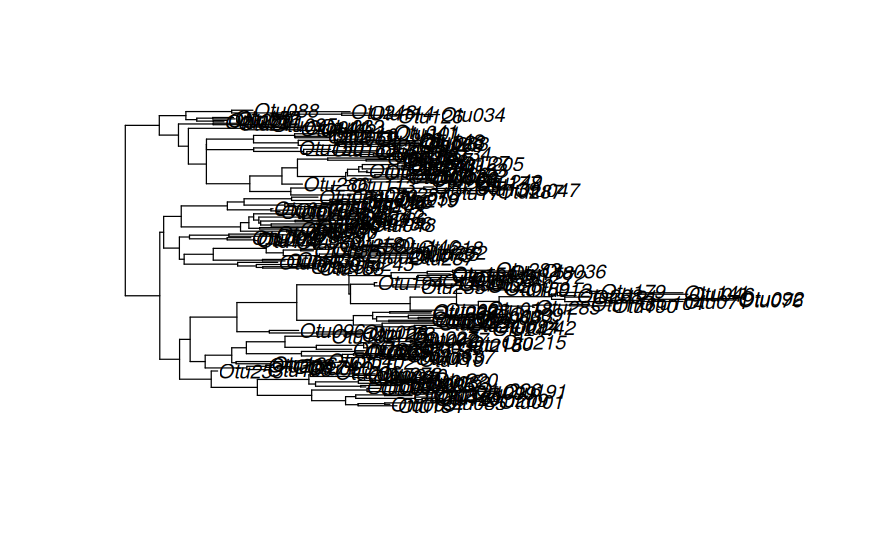

```r
a<-as.data.frame(tax_mat)
random_tree = ape::rtree(ntaxa(carbom), rooted=TRUE, tip.label=taxa(carbom))
plot(random_tree)
```

```r
carbom1 = merge_phyloseq(carbom, random_tree)
carbom1
```

```
phyloseq-class experiment-level object
otu_table()   OTU Table:         [ 205 taxa and 54 samples ]
sample_data() Sample Data:       [ 54 samples by 27 sample variables ]
tax_table()   Taxonomy Table:    [ 205 taxa by 7 taxonomic ranks ]
phy_tree()    Phylogenetic Tree: [ 205 tips and 204 internal nodes ]
```

#Basic bar graph based on Division

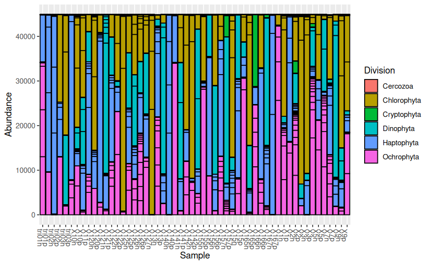

```r
  plot_bar(carbom, fill="Division")
```

#Make the bargraph nicer by removing OTUs boundaries. This is done by adding ggplot2 modifier.

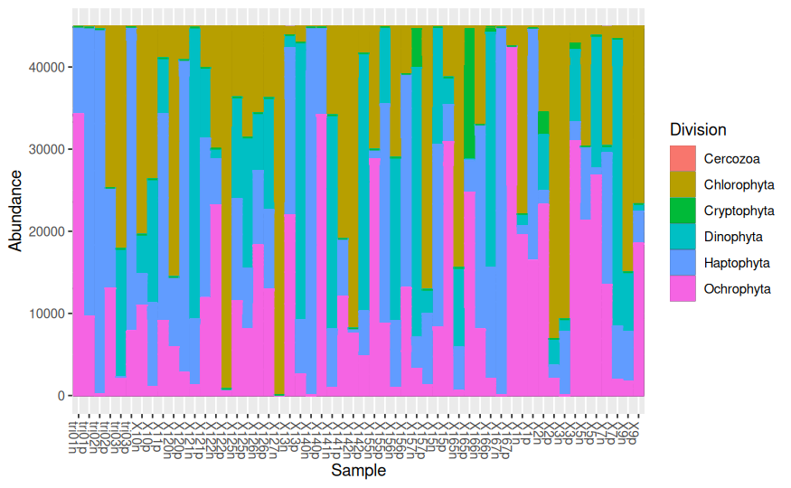

```r
  plot_bar(carbom, fill = "Division") +
  geom_bar(aes(color=Division, fill=Division),position = "stack", stat="identity")
```

#Regroup together Pico vs Nano samples

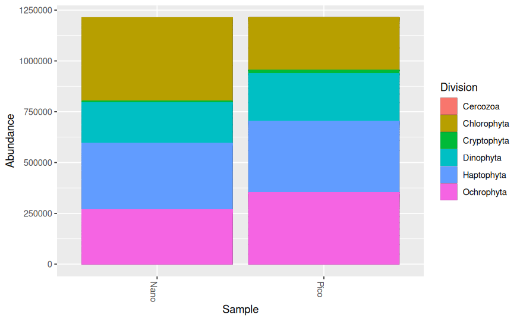

```r
  carbom_fraction <- merge_samples(carbom, "fraction")
  plot_bar(carbom_fraction, fill = "Division") +
  geom_bar(aes(color=Division, fill=Division), stat="identity", position="stack")
```

#Keep only Chlorophyta and use color according to genus. Do separate panels Pico vs Nano and Surface vs Deep samples.

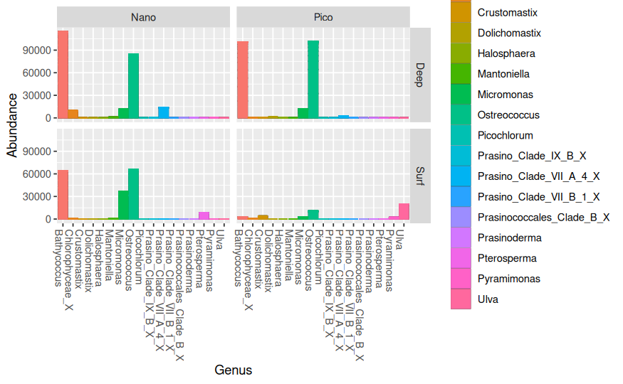

```r
  carbom_chloro <- subset_taxa(carbom, Division %in% c("Chlorophyta"))
  plot_bar(carbom_chloro, x="Genus", fill = "Genus", facet_grid = level~fraction) +
  geom_bar(aes(color=Genus, fill=Genus), stat="identity", position="stack")
```

## Heatmaps

A basic heatmap using the default parameters.

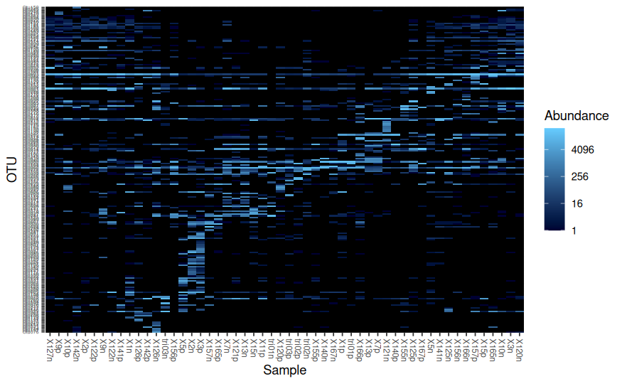

```r
  plot_heatmap(carbom, method = "NMDS", distance = "bray")
```

### It is very very cluttered. It is better to only consider the most abundant OTUs for heatmaps. For example one can only take OTUs that represent at least 20% of reads in at least one sample. Remember we normalized all the sampples to median number of reads (total). We are left with only 33 OTUS which makes the reading much more easy.

```r
  carbom_abund <- filter_taxa(carbom, function(x) sum(x > total*0.20) > 0, TRUE)
  carbom_abund
```

```
phyloseq-class experiment-level object
otu_table()   OTU Table:         [ 33 taxa and 54 samples ]
sample_data() Sample Data:       [ 54 samples by 27 sample variables ]
tax_table()   Taxonomy Table:    [ 33 taxa by 7 taxonomic ranks ]
```

```r
  otu_table(carbom_abund)[1:8, 1:5]
```

```
OTU Table:          [8 taxa and 5 samples]
                     taxa are rows
        X10n  X10p  X11p X120n X120p
Otu001 13339  7346  3804 12662     3
Otu002    18  8329 14958    30 36206
Otu003  9692 10488    20 16537    11
Otu004  3584  4943    33     7     9
Otu005     0     6    11     0     5
Otu006     0     9     0     0     5
Otu007  4473   605   587  5894     3
Otu008     1     9  6707     2    17
```

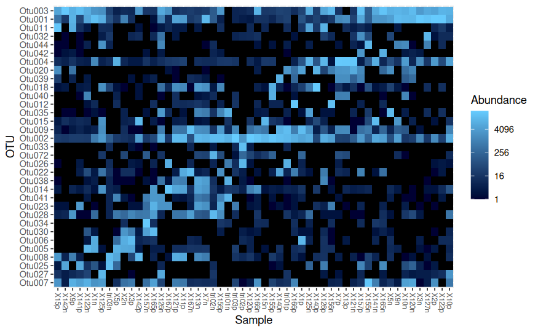

```r
  plot_heatmap(carbom_abund, method = "NMDS", distance = "bray")
```

#It is possible to use different distances and different multivaraite methods. For example Jaccard distance and MDS and label OTUs with Class, order by Class. We can also change the Palette (the default palette is a bit ugly…).

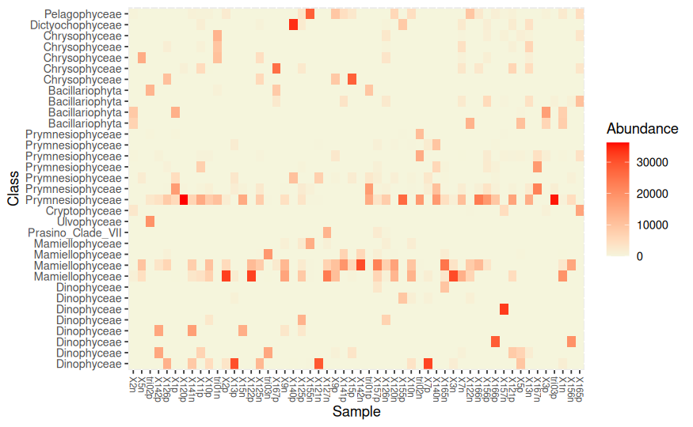

```r
  plot_heatmap(carbom_abund, method = "MDS", distance = "(A+B-2*J)/(A+B-J)",
               taxa.label = "Class", taxa.order = "Class",
               trans=NULL, low="beige", high="red", na.value="beige")
```

```r
dist_methods <- unlist(distanceMethodList)
print(dist_methods)
```

```
    UniFrac1     UniFrac2        DPCoA          JSD     vegdist1     vegdist2     vegdist3
   "unifrac"   "wunifrac"      "dpcoa"        "jsd"  "manhattan"  "euclidean"   "canberra"
    vegdist4     vegdist5     vegdist6     vegdist7     vegdist8     vegdist9    vegdist10
      "bray" "kulczynski"    "jaccard"      "gower"   "altGower"   "morisita"       "horn"
   vegdist11    vegdist12    vegdist13    vegdist14    vegdist15   betadiver1   betadiver2
 "mountford"       "raup"   "binomial"       "chao"        "cao"          "w"         "-1"
  betadiver3   betadiver4   betadiver5   betadiver6   betadiver7   betadiver8   betadiver9
         "c"         "wb"          "r"          "I"          "e"          "t"         "me"
 betadiver10  betadiver11  betadiver12  betadiver13  betadiver14  betadiver15  betadiver16
         "j"        "sor"          "m"         "-2"         "co"         "cc"          "g"
 betadiver17  betadiver18  betadiver19  betadiver20  betadiver21  betadiver22  betadiver23
        "-3"          "l"         "19"         "hk"        "rlb"        "sim"         "gl"
 betadiver24        dist1        dist2        dist3   designdist
         "z"    "maximum"     "binary"  "minkowski"        "ANY"
```

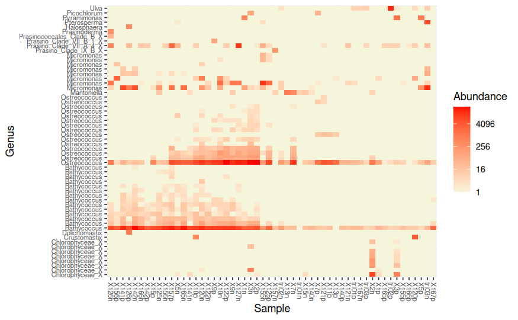

```r
  plot_heatmap(carbom_chloro, method = "NMDS", distance = "bray",
               taxa.label = "Genus", taxa.order = "Genus",
               low="beige", high="red", na.value="beige")
```

## Alpha diversity

Plot Chao1 richness estimator and Shannon diversity estimator.

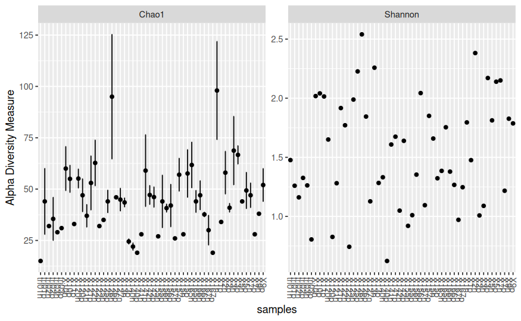

```r
  plot_richness(carbom, measures=c("Chao1", "Shannon"))
```

Regroup together samples from the same fraction.

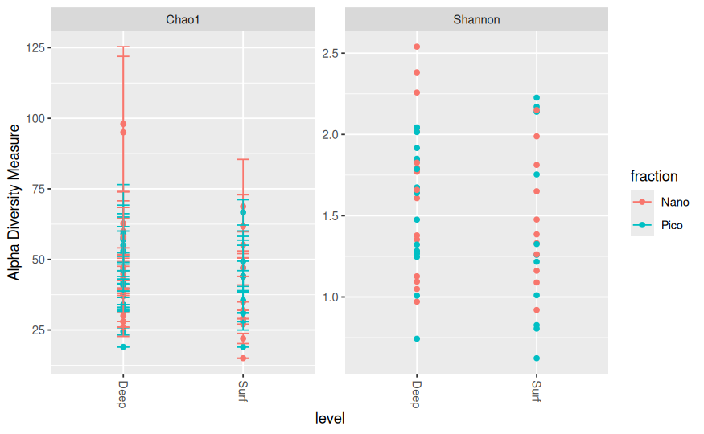

```r
  plot_richness(carbom, measures=c("Chao1", "Shannon"), x="level", color="fraction")
```